# Example: Fitting Traits with JAGS (Bayesian Inference)

Marta Shocket, Mordecai Lab at Stanford University

6/7/2018

## Set up workspace

```r
# Set working directory
# setwd('')

# Load libraries
require(R2jags)
```

```r
require(mcmcplots) # for diagnostic plots
# Load data
Aaeg.data <- read.csv("~/Documents/GitHub/VBiTraining/data/AeaegyptiTraitData.csv")
```

## Data exploration and preparation

### Inspect the data set

Note that there are several different traits, and some of the traits come in multiple forms (e.g., mu and 1/mu).

The traits we have data for are:  
- pEA: proportion surviving from egg to adulthood  
- MDR: mosquito development rate  
- PDR: parasite development rate (= 1/EIP the extrinsic incubation period)  
- mu: death rate (= 1/longevity)

```r
# Look at the data (just first 3 columns)
Aaeg.data[,1:3]
```

```
##     trait.name        T       trait
## 1          pEA 22.00000  0.90812000
## 2          pEA 27.00000  0.93590000
## 3          pEA 32.00000  0.81944000
## 4          MDR 22.00000  0.09174000
## 5          MDR 27.00000  0.13587000
## 6          MDR 32.00000  0.15823000
## 7          MDR 21.00000  0.06161000
## 8          MDR 24.00000  0.07599000
## 9          MDR 27.00000  0.08688000
## 10         MDR 30.00000  0.10081000
## 11         PDR 22.00000  0.04000000
## 12         PDR 24.00000  0.05000000
## 13         PDR 26.00000  0.07000000
## 14         PDR 28.00000  0.08000000
```

[output cut: 139 more lines]

### Subset and plot the mu and lifespan data

Note that the mu data is u-shaped and the lifespan data is unimodal (hump-shaped).  
Since thermal biology theory is based on unimodal thermal responses, we’ll need to convert the mu data to lifespan by taking the inverse.

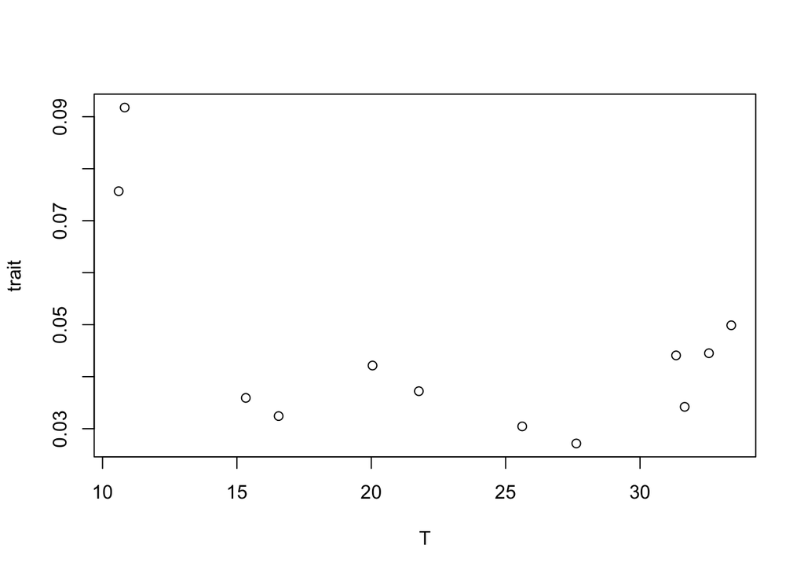

```r
mu.data <- subset(Aaeg.data, trait.name == "mu")
lf.data <- subset(Aaeg.data, trait.name == "1/mu")

plot(trait ~ T, data = mu.data)
```

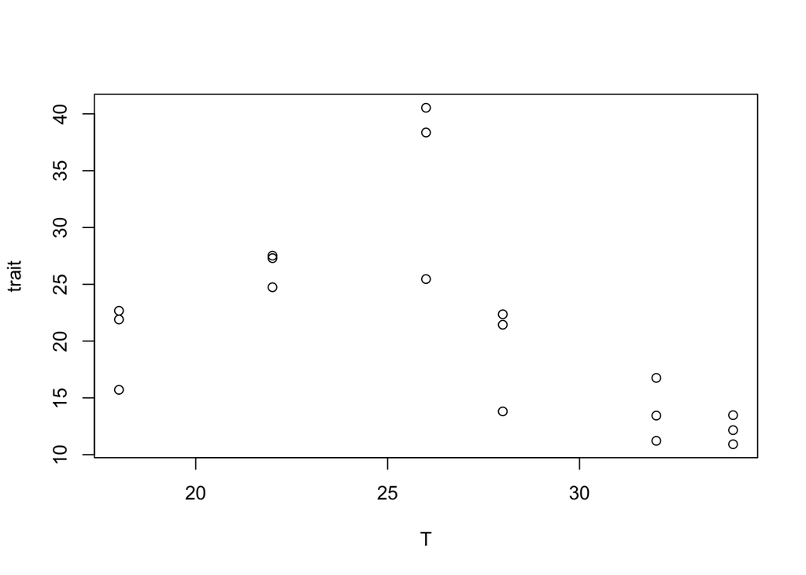

```r
plot(trait ~ T, data = lf.data)
```

### Combine mu and lifespan data and replot them together

Now the data have a nice unimodal shape that we can fit a function to.

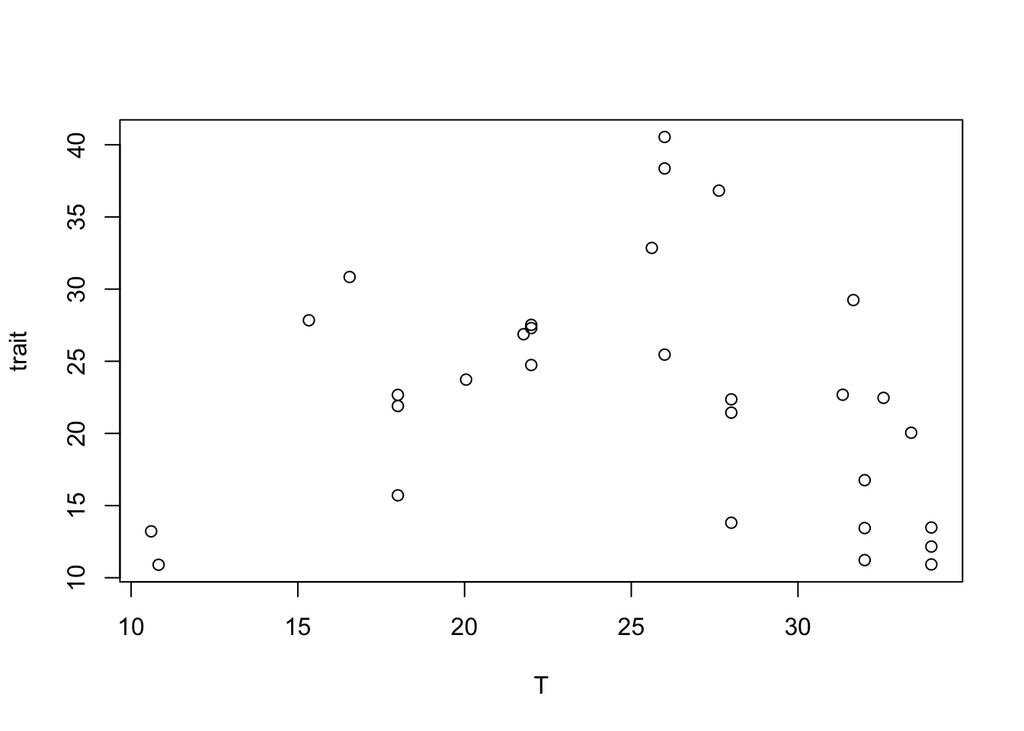

```r
mu.data.inv <- mu.data # make a copy of the mu data
mu.data.inv$trait <- 1/mu.data$trait # take the inverse of the trait values to convert mu to lifespan
lf.data.comb <- rbind(mu.data.inv, lf.data) # combine both lifespan data sets together

plot(trait ~ T, data = lf.data.comb)
```

## Fitting a trait thermal response curve using JAGS

### The two thermal responses

Most thermal response curves can be reasonably fit using one of two thermal reponses: traits that respond symmetrically to temperature are fit with a quadratic function and traits that respond assymetrically to temperature are fit with a Briere function. In both functions, T0 is the lower thermal limit and Tm is the upper thermal limit (i.e., where the trait value goes to zero) and q scales the value at the optimum.

Quadratic function: -1*q*(T-T0)(T-Tm)  
Briere function: qT*(T-T0)*sqrt(Tm-T)

### The thermal response model file

JAGS needs the model written as a .txt file inside your the working directory. You can either make the text file directly, or create it using the sink() function via your R script (see below).  
The model file has two mandatory sections (the priors and the likelihood) and one optional section (derived quantiaties calculated from your fitted parameters).  
In the example below for a quadratic function, most of the priors are specified via uniform distributions (the two arguments specific the lower and upper bounds, respectively). Note that unlike in R and most other programs, in JAGS the normal distribution uses tau instead of sigma (tau = 1/(sigma^2)).  
The likelihood for can be interpreted as follows: the observed data are normally distributed where the mean at a given temperatuer follows the quadratic equation

```r
sink("quad.txt")
cat("
    model{

    ## Priors
    cf.q ~ dunif(0, 1)
    cf.T0 ~ dunif(0, 24)
    cf.Tm ~ dunif(25, 45)
    cf.sigma ~ dunif(0, 1000)
    cf.tau <- 1 / (cf.sigma * cf.sigma)

    ## Likelihood
    for(i in 1:N.obs){
    trait.mu[i] <- -1 * cf.q * (temp[i] - cf.T0) * (temp[i] - cf.Tm) * (cf.Tm > temp[i]) * (cf.T0 < temp[i])
    trait[i] ~ dnorm(trait.mu[i], cf.tau)
    }

    ## Derived Quantities and Predictions
    for(i in 1:N.Temp.xs){
    z.trait.mu.pred[i] <- -1 * cf.q * (Temp.xs[i] - cf.T0) * (Temp.xs[i] - cf.Tm) * (cf.Tm > Temp.xs[i]) * (cf.T0 < Temp.xs[i])
    }

    } # close model
    ",fill=T)
sink()
```

### Additional settings for JAGS

```r
# Parameters to Estimate
parameters <- c("cf.q", "cf.T0", "cf.Tm","cf.sigma", "z.trait.mu.pred")

# Initial values for the parameters
inits<-function(){list(
  cf.q = 0.01,
  cf.Tm = 35,
  cf.T0 = 5,
  cf.sigma = rlnorm(1))}

# MCMC Settings: number of posterior dist elements = [(ni - nb) / nt ] * nc
ni <- 25000 # number of iterations in each chain
nb <- 5000 # number of 'burn in' iterations to discard
nt <- 8 # thinning rate - jags saves every nt iterations in each chain
nc <- 3 # number of chains

# Temperature sequence for derived quantity calculations
Temp.xs <- seq(5, 45, 0.2)
N.Temp.xs <-length(Temp.xs)
```

### Fitting the trait thermal response

```r
# Pull out data columns as vectors
data <- lf.data.comb # this lets us reuse the same generic code: we only change this first line
trait <- data$trait
N.obs <- length(trait)
temp <- data$T

# Bundle all data in a list for JAGS
jag.data<-list(trait = trait, N.obs = N.obs, temp = temp, Temp.xs = Temp.xs, N.Temp.xs = N.Temp.xs)

# Run JAGS
lf.fit <- jags(data=jag.data, inits=inits, parameters.to.save=parameters, model.file="quad.txt",
                       n.thin=nt, n.chains=nc, n.burnin=nb, n.iter=ni, DIC=T, working.directory=getwd())
```

```
## module glm loaded
```

### Running diagnostics

```r
# View the parameters - only the first 5 lines (otherwise it will also show you all of your derived quantities)
lf.fit$BUGSoutput$summary[1:5,]
```

```
##                mean         sd         2.5%          25%         50%
## cf.T0      6.577796 2.08150836   1.62550763   5.38727683   6.8854256
## cf.Tm     39.213914 1.68498844  36.57348321  38.00562299  38.9704002
## cf.q       0.110759 0.02598391   0.06341003   0.09283825   0.1098812
## cf.sigma   6.685957 0.96368003   5.12578595   5.99293561   6.5799630
## deviance 197.627768 3.01541008 193.77032271 195.36160948 196.9969508
##                  75%       97.5%     Rhat n.eff
## cf.T0      8.0318665   9.8873136 1.003543  3300
## cf.Tm     40.1343207  43.3623786 1.001968  3500
## cf.q       0.1274354   0.1631144 1.001993  3700
## cf.sigma   7.2582447   8.8479357 1.000822  7500
## deviance 199.2211173 204.9930970 1.001552  2700
```

```r
# mcmcplot will open an html file in your default browse and allow you to look at the chains for convergence and autocorrelation
mcmcplot(lf.fit)
```

[output not shown]

[output not shown]

[output not shown]

[output not shown]

[output not shown]

[output not shown]

[output not shown]

[output not shown]

[output not shown]

[output not shown]

[output not shown]

[output not shown]

[output not shown]

[output not shown]

[output not shown]

[output not shown]

[output not shown]

[output not shown]

[output not shown]

[output not shown]

[output not shown]

[output not shown]

[output not shown]

[output not shown]

[output not shown]

[output not shown]

[output not shown]

[output not shown]

[output not shown]

[output not shown]

[output not shown]

[output not shown]

[output not shown]

[output not shown]

[output not shown]

[output not shown]

[output not shown]

[output not shown]

[output not shown]

[output not shown]

[output not shown]

[output not shown]

[output not shown]

[output not shown]

[output not shown]

[output not shown]

[output not shown]

[output not shown]

[output not shown]

[output not shown]

[output not shown]

[output not shown]

[output not shown]

[output not shown]

[output not shown]

[output not shown]

[output not shown]

[output not shown]

[output not shown]

[output not shown]

[output not shown]

[output not shown]

[output not shown]

[output not shown]

[output not shown]

[output not shown]

[output not shown]

[output not shown]

[output not shown]

[output not shown]

[output not shown]

[output not shown]

[output not shown]

[output not shown]

[output not shown]

[output not shown]

[output not shown]

[output not shown]

[output not shown]

[output not shown]

[output not shown]

[output not shown]

[output not shown]

[output not shown]

[output not shown]

[output not shown]

[output not shown]

[output not shown]

[output not shown]

[output not shown]

[output not shown]

[output not shown]

[output not shown]

[output not shown]

[output not shown]

[output not shown]

[output not shown]

[output not shown]

[output not shown]

[output not shown]

[output not shown]

[output not shown]

[output not shown]

[output not shown]

[output not shown]

[output not shown]

[output not shown]

[output not shown]

[output not shown]

[output not shown]

[output not shown]

[output not shown]

[output not shown]

[output not shown]

[output not shown]

[output not shown]

[output not shown]

[output not shown]

[output not shown]

[output not shown]

[output not shown]

[output not shown]

[output not shown]

[output not shown]

[output not shown]

[output not shown]

[output not shown]

[output not shown]

[output not shown]

[output not shown]

[output not shown]

[output not shown]

[output not shown]

[output not shown]

[output not shown]

[output not shown]

[output not shown]

[output not shown]

[output not shown]

[output not shown]

[output not shown]

[output not shown]

[output not shown]

[output not shown]

[output not shown]

[output not shown]

[output not shown]

[output not shown]

[output not shown]

[output not shown]

[output not shown]

[output not shown]

[output not shown]

[output not shown]

[output not shown]

[output not shown]

[output not shown]

[output not shown]

[output not shown]

[output not shown]

[output not shown]

[output not shown]

[output not shown]

[output not shown]

[output not shown]

[output not shown]

[output not shown]

[output not shown]

[output not shown]

[output not shown]

[output not shown]

[output not shown]

[output not shown]

[output not shown]

[output not shown]

[output not shown]

[output not shown]

[output not shown]

[output not shown]

### Plot thermal response

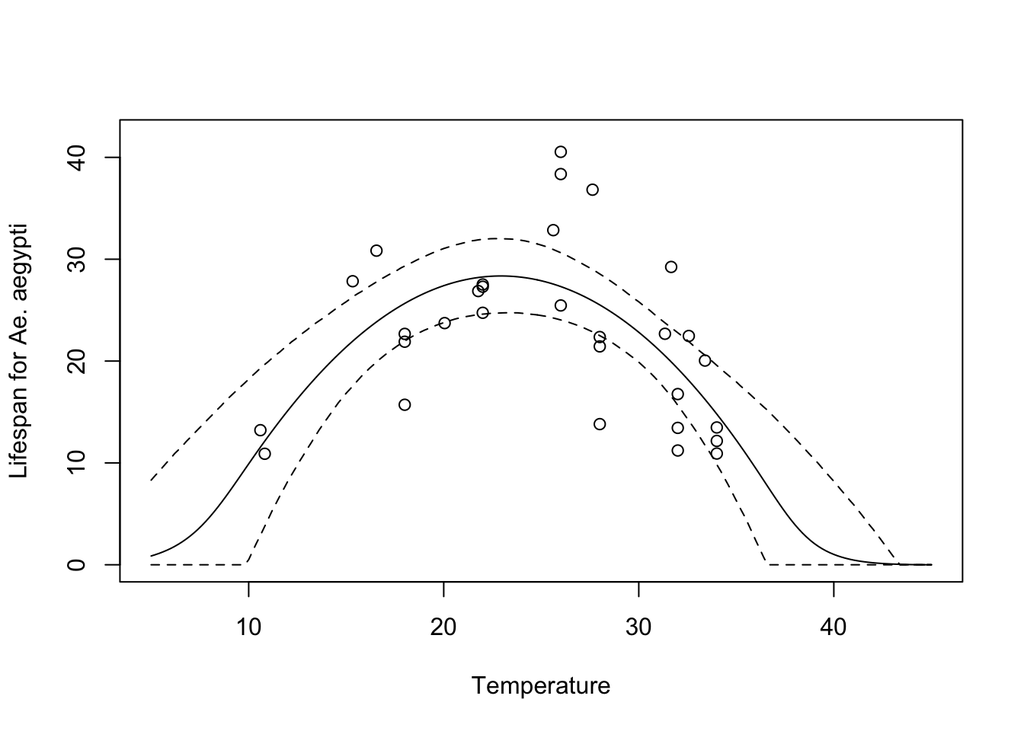

```r
plot(trait ~ T, xlim = c(5, 45), ylim = c(0,42), data = lf.data.comb, ylab = "Lifespan for Ae. aegypti", xlab = "Temperature")
lines(lf.fit$BUGSoutput$summary[6:(6 + N.Temp.xs - 1), "2.5%"] ~ Temp.xs, lty = 2)
lines(lf.fit$BUGSoutput$summary[6:(6 + N.Temp.xs - 1), "97.5%"] ~ Temp.xs, lty = 2)
lines(lf.fit$BUGSoutput$summary[6:(6 + N.Temp.xs - 1), "mean"] ~ Temp.xs)
```